# Desafio 14

Author

Nicole de Barros Silva

# **Laboratório 4: Visualização de Dados com `plotnine`**

## **Objetivo**

Criar visualizações adequadas utilizando a biblioteca `plotnine`. A atividade será baseada em um conjunto de dados com o qual é necessário realizar agregação, filtragem e transformação de dados antes de aplicar estratégias de visualização.

## **O Conjunto de Dados**

O conjunto de dados para esta atividade é o `diamonds`, que está disponível na biblioteca `plotnine.data`. O conjunto de dados `diamonds` contém informações sobre 53.940 diamantes. Ele é amplamente utilizado para a prática de visualização e análise de dados e contém as seguintes variáveis:

| Variável | Tipo | Descrição |
| --- | --- | --- |
| `carat` | Numérica | Peso do diamante, em quilates (carats). |
| `cut` | Categórica | Qualidade do corte do diamante (Fair, Good, Very Good, Premium, Ideal). |
| `color` | Categórica | Cor do diamante, onde D é a melhor (mais transparente) e J é a pior. |
| `clarity` | Categórica | Clareza do diamante, categorizada por um padrão internacional (IF, VVS1, VVS2, etc.). |
| `depth` | Numérica | Profundidade total do diamante como porcentagem da média do diâmetro. |
| `table` | Numérica | Largura da parte superior do diamante (mesa) como uma porcentagem da largura total. |
| `price` | Numérica | Preço do diamante, em dólares. |
| `x` | Numérica | Comprimento do diamante, em milímetros. |
| `y` | Numérica | Largura do diamante, em milímetros. |
| `z` | Numérica | Altura do diamante, em milímetros. |

### **Significado das Variáveis Categóricas**

- **Cut (Corte):**
  - *Fair*
  - *Good*
  - *Very Good*
  - *Premium*
  - *Ideal*
- **Color (Cor):**
  - D (Melhor)
  - E
  - F
  - G
  - H
  - I
  - J (Pior)
- **Clarity (Clareza):**
  - IF (Internally Flawless)
  - VVS1 (Very, Very Slightly Included 1)
  - VVS2 (Very, Very Slightly Included 2)
  - VS1 (Very Slightly Included 1)
  - VS2 (Very Slightly Included 2)
  - SI1 (Slightly Included 1)
  - SI2 (Slightly Included 2)
  - I1 (Included 1)

### **Observações Importantes:**

- **Preço**: O preço dos diamantes varia de USD 326 a USD 18.823.
- **Peso (Carat)**: A variável `carat` vai de 0,2 a 5,01 quilates.
- **Proporções**: As variáveis `x`, `y` e `z` representam as dimensões físicas do diamante em milímetros.

Este conjunto de dados é amplamente utilizado para explorar a relação entre variáveis categóricas (como `cut`, `color`, `clarity`) e numéricas (`price`, `carat`, etc.), especialmente em análises de regressão e visualizações de dados.

## **Atividades**

```r
library(reticulate) #abre o pacote reticulate
```

```r
virtualenv_create("r-reticulate", python = "C:/Program Files/Python312/python.exe") #cria um ambiente virtual para usar python
```

```
virtualenv: r-reticulate
```

```r
use_virtualenv("r-reticulate", required = TRUE) #manda usar o ambiente virtual criado
py_config() # mostra as informações de configuração do Python que o reticulate está usando
```

```
python:         \\smb/ra238935/Documentos/.virtualenvs/r-reticulate/Scripts/python.exe
libpython:      C:/Program Files/Python312/python312.dll
pythonhome:     \\smb/ra238935/Documentos/.virtualenvs/r-reticulate
version:        3.12.0 (tags/v3.12.0:0fb18b0, Oct  2 2023, 13:03:39) [MSC v.1935 64 bit (AMD64)]
Architecture:   64bit
numpy:          \\smb/ra238935/Documentos/.virtualenvs/r-reticulate/Lib/site-packages/numpy
numpy_version:  2.3.2

NOTE: Python version was forced by use_python() function
```

```r
# Instala o pacote "polars" dentro do ambiente virtual "r-reticulate"
py_install("polars", envname = "r-reticulate")
```

```
Using virtual environment "r-reticulate" ...
```

```
+ //smb/ra238935/Documentos/.virtualenvs/r-reticulate/Scripts/python.exe -m pip install --upgrade --no-user polars
```

```r
# Instala o pacote "plotnine" dentro do ambiente virtual "r-reticulate"
py_install("plotnine", envname = "r-reticulate")
```

```
Using virtual environment "r-reticulate" ...
```

```
+ //smb/ra238935/Documentos/.virtualenvs/r-reticulate/Scripts/python.exe -m pip install --upgrade --no-user plotnine
```

1. Importe o conjunto de dados `diamonds`, cujo arquivo está disponível no website da disciplina.

```python
# Importa o conjunto de dados "diamonds" da biblioteca plotnine.data
from plotnine.data import diamonds
print(diamonds.head())
```

```
   carat      cut color clarity  depth  table  price     x     y     z
0   0.23    Ideal     E     SI2   61.5   55.0    326  3.95  3.98  2.43
1   0.21  Premium     E     SI1   59.8   61.0    326  3.89  3.84  2.31
2   0.23     Good     E     VS1   56.9   65.0    327  4.05  4.07  2.31
3   0.29  Premium     I     VS2   62.4   58.0    334  4.20  4.23  2.63
4   0.31     Good     J     SI2   63.3   58.0    335  4.34  4.35  2.75
```

2. Crie uma visualização de dados que descreva a associação existente entre as variáveis peso (`carat`) e preço (`price`). Que ações você tomou para garantir que você produziu um gráfico de boa qualidade? Escreva um parágrafo comunicando os seus achados.

```python
# Importa as funções necessárias da biblioteca plotnine para criar o gráfico
from plotnine import ggplot, aes, geom_point, labs, theme_minimal, scale_x_continuous, scale_y_continuous

# Cria o gráfico de dispersão entre o peso (carat) e o preço (price) dos diamantes
a = (
    ggplot(diamonds, aes(x='carat', y='price')) +
    geom_point(alpha=0.4, color='blue') +  # transparência para sobreposição
    scale_x_continuous(limits=(0, 5)) +    # focar nos diamantes mais comuns
    scale_y_continuous(limits=(0, 20000)) +
    labs(
        title='Relação entre Peso (carat) e Preço dos Diamantes',
        x='Peso (carat)',
        y='Preço (USD)'
    ) +
    theme_minimal()  # tema limpo e profissional
)
# Salva o gráfico gerado em um arquivo de imagem PNG
a.save("a.png")
```

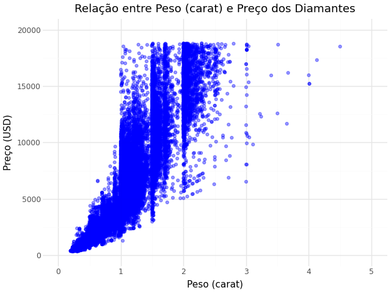

```r
# Exibe o gráfico salvo anteriormente ("a.png")
knitr::include_graphics("a.png")
```

Boas práticas aplicadas: -Transparência (alpha=0.4): ajuda a visualizar a densidade de pontos mesmo com sobreposição. -Limites dos eixos: foca nos diamantes mais comuns e evita que outliers distorçam a visualização. -Tema minimalista: deixa o gráfico limpo e legível. -Cores suaves: azul para os pontos, agradável à visualização. -Títulos e labels claros: comunicação precisa do que está sendo mostrado.

O gráfico mostra uma relação positiva entre o peso (carat) e o preço (price) dos diamantes: conforme o peso aumenta, o preço tende a crescer. No entanto, há dispersão, principalmente para diamantes maiores, mostrando que nem todos os diamantes mais pesados seguem um padrão linear exato de preço. A maioria dos diamantes está concentrada com até 2 carats e preços abaixo de 10.000 USD, indicando que outliers com preços muito altos ou pesos muito grandes são relativamente raros, mas influenciam a distribuição geral dos dados.

3. A relação identificada na questão anterior é a mesma relação presente nos diferentes cortes de diamantes? Crie uma visualização que demonstre seus achados eficientemente. Descreva sua conclusão em um parágrafo.

```python
# Importa as funções necessárias da biblioteca plotnine para criação do gráfico
from plotnine import (
    ggplot, aes, geom_point, geom_smooth, facet_wrap,
    labs, theme_minimal, theme, element_text
)
# Cria o gráfico de dispersão mostrando a relação entre peso (carat) e preço (price) e divide o gráfico por tipo de corte (cut)
b = (
    ggplot(diamonds, aes(x='carat', y='price')) +
    geom_point(alpha=0.3, color='#1f77b4', size=1.2) +  # azul padrão, transparente
    geom_smooth(method='lm', color='red', se=False, size=1) +  # linha de tendência
    facet_wrap('~cut', ncol=3) +  # organiza os facets em 3 colunas
    labs(
        title='Relação entre Peso (Carat) e Preço (USD) por Corte do Diamante',
        x='Peso (carat)',
        y='Preço (USD)'
    ) +
    theme_minimal(base_size=12) +
    theme(
        plot_title=element_text(size=14, weight='bold', ha='center'),
        axis_title=element_text(size=12),
        axis_text=element_text(size=10),
        strip_text=element_text(size=11, weight='bold'),
        figure_size=(10, 6)
    )
)
# Salva o gráfico gerado em um arquivo de imagem PNG
b.save("b.png")
```

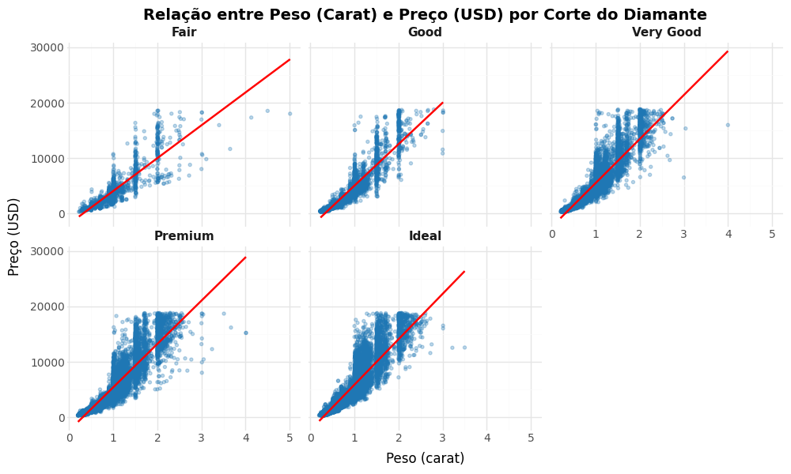

```r
# Exibe o gráfico salvo anteriormente ("b.png")
knitr::include_graphics("b.png")
```

O gráfico mostra que a relação positiva entre o peso (carat) e o preço (price) se mantém em todos os tipos de corte de diamante. Observa-se que cortes de maior qualidade, como Ideal e Premium, apresentam preços mais altos para o mesmo peso em comparação aos cortes Fair e Good. Além disso, o aumento do peso tende a elevar o preço de forma acentuada, mas com maior dispersão para valores altos de carat. Assim, o corte influencia a escala de preço, mas a tendência geral de crescimento permanece consistente entre os grupos.

4. Crie uma visualização que mostre a relação entre preço e peso do diamante, considerando as diferentes combinações de qualidade de corte, cor e clareza do diamante. Quais foram as dificuldades encontradas? A relação entre preço e peso é a mesma para diferentes configurações de diamantes?

```python
# Importa as funções necessárias da biblioteca plotnine para construção do gráfico
from plotnine import (
    ggplot, aes, geom_point,
    facet_grid, labs, theme_minimal, theme, element_text
)

#Cria o gráfico de dispersão mostrando a relação entre preço (price) e peso (carat) considerando, simultaneamente, as variáveis categóricas: corte (cut), cor (color) e clareza (clarity)
c = (
    ggplot(diamonds, aes(x='carat', y='price', color='clarity')) +
    geom_point(alpha=0.3, size=1) +
    facet_grid('cut ~ color') +  # linhas = corte, colunas = cor
    labs(
        title='Relação entre Preço e Peso do Diamante\npor Corte, Cor e Clareza',
        x='Peso (carat)',
        y='Preço (USD)',
        color='Clareza'
    ) +
    theme_minimal(base_size=11) +
    theme(
        plot_title=element_text(size=14, weight='bold', ha='center'),
        axis_title=element_text(size=11),
        axis_text=element_text(size=9),
        strip_text=element_text(size=10, weight='bold'),
        legend_title=element_text(size=10),
        legend_text=element_text(size=9),
        figure_size=(11, 7)
    )
)
# Salva o gráfico gerado como uma imagem PNG
c.save("c.png")
```

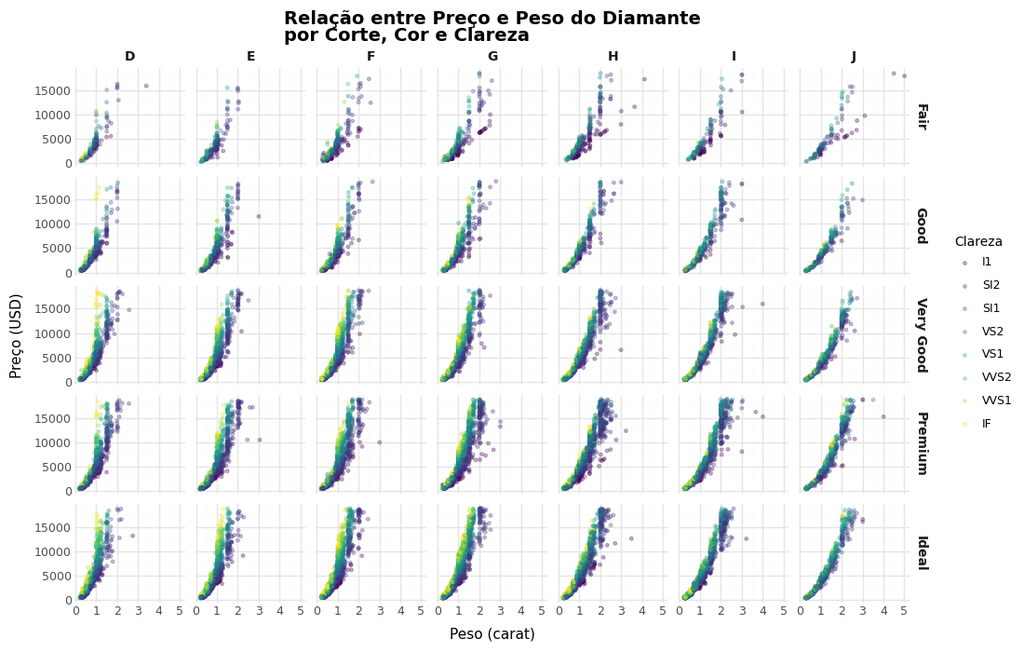

```r
# Exibe a imagem "c.png"
knitr::include_graphics("c.png")
```

A visualização mostra a relação positiva entre peso (carat) e preço (price) em todas as combinações de corte, cor e clareza. No entanto, percebe-se que a inclinação da relação varia conforme a qualidade: cortes mais refinados e cores mais raras tendem a apresentar preços mais elevados para o mesmo peso. A clareza também exerce influência — diamantes mais puros (alta clareza) costumam concentrar-se nas faixas de preço mais altas. Uma das principais dificuldades encontradas foi a densidade e sobreposição de pontos, já que o conjunto diamonds contém mais de 50.000 observações. Além disso, representar simultaneamente três variáveis categóricas e duas numéricas exige muito cuidado para evitar poluição visual. Mesmo assim, o padrão geral se mantém: o preço cresce com o peso, mas o ritmo desse crescimento depende fortemente da combinação de corte, cor e clareza.

```r
# Registra quando o html foi gerado
cat(paste0("Este HTML foi gerado em: ", Sys.time()))
```

```
Este HTML foi gerado em: 2025-10-30 12:28:31.199397
```